# Praca domowa 1

Aleksandra Palka

2022-10-10

**ZADANIE 1**  
Wprowadzam dwie zmienne

```r
pierwsza <- c(4, 20, 21, 34, 11, 9, 23, 122)
druga <- c(42, 1, 56, 123, 99, 12, 22, 90)
```

Wywołuję zmienne

```r
pierwsza
```

```
## [1]   4  20  21  34  11   9  23 122
```

```r
druga
```

```
## [1]  42   1  56 123  99  12  22  90
```

Wyznaczam zmienne: suma, różnica, więcej

```r
suma <- pierwsza + druga
roznica <- pierwsza - druga
wiecej <- pierwsza + 1
```

Suma wynosi: 46, 21, 77, 157, 110, 21, 45, 212. Różnica wynosi: -38, 19, -35, -89, -88, -3, 1, 32. Więcej: 5, 21, 22, 35, 12, 10, 24, 123.

Średnia arytmetyczna wyznaczona za pomocą funkcji mean() oraz odchylenie standardowe wyznaczone za pomocą funkcji sd():

```r
mean(pierwsza)
```

```
## [1] 30.5
```

```r
mean(druga)
```

```
## [1] 55.625
```

```r
sd(pierwsza)
```

```
## [1] 38.14633
```

```r
sd(druga)
```

```
## [1] 44.41022
```

Średnia arytmetyczna pierwszego zestawu wynosi 30.5. Odchylenie standardowe durgiego zestawu wynosi 44.4102224.

**ZADANIE 2**  
Tworzę ramkę z danymi (nazywam ją osoby), która przechowuje obserwacje o wzroście oraz wadze

```r
osoby <- data.frame("wzrost" = c(1.76, 1.60, 1.98, 1.68, 1.88, 1.65, 1.71),
                    "waga" = c(62, 120, 90, 55, 73, 56, 63))
```

Ramka osoby wygląda w następujący sposób:

```r
osoby
```

```
##   wzrost waga
## 1   1.76   62
## 2   1.60  120
## 3   1.98   90
## 4   1.68   55
## 5   1.88   73
## 6   1.65   56
## 7   1.71   63
```

Struktura obiektu

```r
str(osoby)
```

```
## 'data.frame':    7 obs. of  2 variables:
##  $ wzrost: num  1.76 1.6 1.98 1.68 1.88 1.65 1.71
##  $ waga  : num  62 120 90 55 73 56 63
```

Poznaję kilka pierwszych obiektów w zbiorze

```r
head(osoby)
```

```
##   wzrost waga
## 1   1.76   62
## 2   1.60  120
## 3   1.98   90
## 4   1.68   55
## 5   1.88   73
## 6   1.65   56
```

Poznaję kilka ostatnich obiektów w zbiorze

```r
tail(osoby)
```

```
##   wzrost waga
## 2   1.60  120
## 3   1.98   90
## 4   1.68   55
## 5   1.88   73
## 6   1.65   56
## 7   1.71   63
```

Poznaję rozmiar obiektu

```r
dim(osoby)
```

```
## [1] 7 2
```

Wyznaczam podstawowe statystyki opisowe w obiekcie

```r
summary(osoby)
```

```
##      wzrost           waga
##  Min.   :1.600   Min.   : 55.00
##  1st Qu.:1.665   1st Qu.: 59.00
##  Median :1.710   Median : 63.00
##  Mean   :1.751   Mean   : 74.14
##  3rd Qu.:1.820   3rd Qu.: 81.50
##  Max.   :1.980   Max.   :120.00
```

**ZADANIE 3**  
Nadaje imiona obiektom w ramce osoby

```r
rownames(osoby) <- c("Maja", "Zuza", "Maciek", "Ola", "Kacper", "Natalia", "Martyna")
```

Ramka z imionami

```r
osoby
```

```
##         wzrost waga
## Maja      1.76   62
## Zuza      1.60  120
## Maciek    1.98   90
## Ola       1.68   55
## Kacper    1.88   73
## Natalia   1.65   56
## Martyna   1.71   63
```

Tworzę nowy obiekt BMI

```r
wzrost<-c(175,165,168,182,190,157,169)

waga<- c(75,58,72,76,85,55,62)

BMI<- waga/(wzrost/100)^2
```

Dodaję obiekt BMI do ramki danych

```r
osoby['BMI']<-BMI
```

Ile osób ma BMI mniejsze lub równe 25?

```r
sum(BMI<=25)
```

```
## [1] 6
```

BMI mniejsze lub równe 25 ma 6 osób.

Osoby, których BMI wynosi powyżej 30:

```r
(osoby[osoby$BMI > 30])
```

```
## ramka danych z zerową liczbą kolumn oraz 7 wierszami
```

**ZADANIE 4**

mtcars - zbiór danych zawierający 32 obserwacje, które dotyczą aut

Orange - zbiór danych, ktory zawiera informacje dotyczace pomaranczy

Wczytuję dane o samochodach

```r
data("mtcars")
```

Wyświetlam dane

```r
head(mtcars,32)
```

```
##                      mpg cyl  disp  hp drat    wt  qsec vs am gear carb
## Mazda RX4           21.0   6 160.0 110 3.90 2.620 16.46  0  1    4    4
## Mazda RX4 Wag       21.0   6 160.0 110 3.90 2.875 17.02  0  1    4    4
## Datsun 710          22.8   4 108.0  93 3.85 2.320 18.61  1  1    4    1
## Hornet 4 Drive      21.4   6 258.0 110 3.08 3.215 19.44  1  0    3    1
## Hornet Sportabout   18.7   8 360.0 175 3.15 3.440 17.02  0  0    3    2
## Valiant             18.1   6 225.0 105 2.76 3.460 20.22  1  0    3    1
## Duster 360          14.3   8 360.0 245 3.21 3.570 15.84  0  0    3    4
## Merc 240D           24.4   4 146.7  62 3.69 3.190 20.00  1  0    4    2
## Merc 230            22.8   4 140.8  95 3.92 3.150 22.90  1  0    4    2
## Merc 280            19.2   6 167.6 123 3.92 3.440 18.30  1  0    4    4
## Merc 280C           17.8   6 167.6 123 3.92 3.440 18.90  1  0    4    4
## Merc 450SE          16.4   8 275.8 180 3.07 4.070 17.40  0  0    3    3
## Merc 450SL          17.3   8 275.8 180 3.07 3.730 17.60  0  0    3    3
## Merc 450SLC         15.2   8 275.8 180 3.07 3.780 18.00  0  0    3    3
## Cadillac Fleetwood  10.4   8 472.0 205 2.93 5.250 17.98  0  0    3    4
## Lincoln Continental 10.4   8 460.0 215 3.00 5.424 17.82  0  0    3    4
## Chrysler Imperial   14.7   8 440.0 230 3.23 5.345 17.42  0  0    3    4
## Fiat 128            32.4   4  78.7  66 4.08 2.200 19.47  1  1    4    1
## Honda Civic         30.4   4  75.7  52 4.93 1.615 18.52  1  1    4    2
## Toyota Corolla      33.9   4  71.1  65 4.22 1.835 19.90  1  1    4    1
## Toyota Corona       21.5   4 120.1  97 3.70 2.465 20.01  1  0    3    1
## Dodge Challenger    15.5   8 318.0 150 2.76 3.520 16.87  0  0    3    2
## AMC Javelin         15.2   8 304.0 150 3.15 3.435 17.30  0  0    3    2
## Camaro Z28          13.3   8 350.0 245 3.73 3.840 15.41  0  0    3    4
## Pontiac Firebird    19.2   8 400.0 175 3.08 3.845 17.05  0  0    3    2
## Fiat X1-9           27.3   4  79.0  66 4.08 1.935 18.90  1  1    4    1
## Porsche 914-2       26.0   4 120.3  91 4.43 2.140 16.70  0  1    5    2
## Lotus Europa        30.4   4  95.1 113 3.77 1.513 16.90  1  1    5    2
## Ford Pantera L      15.8   8 351.0 264 4.22 3.170 14.50  0  1    5    4
## Ferrari Dino        19.7   6 145.0 175 3.62 2.770 15.50  0  1    5    6
## Maserati Bora       15.0   8 301.0 335 3.54 3.570 14.60  0  1    5    8
## Volvo 142E          21.4   4 121.0 109 4.11 2.780 18.60  1  1    4    2
```

Wyświetlam auta, które posiadają dokładnie 6 cylindrów

```r
mtcars[mtcars$cyl == 6,]
```

```
##                 mpg cyl  disp  hp drat    wt  qsec vs am gear carb
## Mazda RX4      21.0   6 160.0 110 3.90 2.620 16.46  0  1    4    4
## Mazda RX4 Wag  21.0   6 160.0 110 3.90 2.875 17.02  0  1    4    4
## Hornet 4 Drive 21.4   6 258.0 110 3.08 3.215 19.44  1  0    3    1
## Valiant        18.1   6 225.0 105 2.76 3.460 20.22  1  0    3    1
## Merc 280       19.2   6 167.6 123 3.92 3.440 18.30  1  0    4    4
## Merc 280C      17.8   6 167.6 123 3.92 3.440 18.90  1  0    4    4
## Ferrari Dino   19.7   6 145.0 175 3.62 2.770 15.50  0  1    5    6
```

Jaką przeciętną liczbę koni mechanicznych (zmienna hp) posiadają auta o spalaniu (zmienna mpg) mniejszym niż 20?

```r
liczba <- mtcars$hp[mtcars$mpg <20]
```

```r
mean(liczba)
```

```
## [1] 191.9444
```

Auta o spalaniu mniejszym niż 20 mają przeciętnie 191.9444444 koni mechanicznych.

Wczytuje dane Orange

```r
data("Orange")
```

Histogram dla zestawu danych Orange (zmienna dotycząca obwodu drzew)

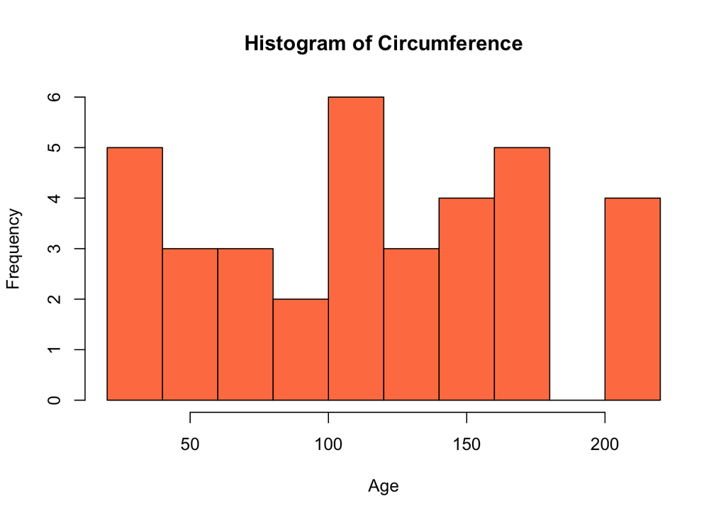

```r
hist(Orange$circumference, col="coral", main = 'Histogram of Circumference', xlab='Age')
```

Wykres pudełkowy z wąsem dla zestawu danych mtcars

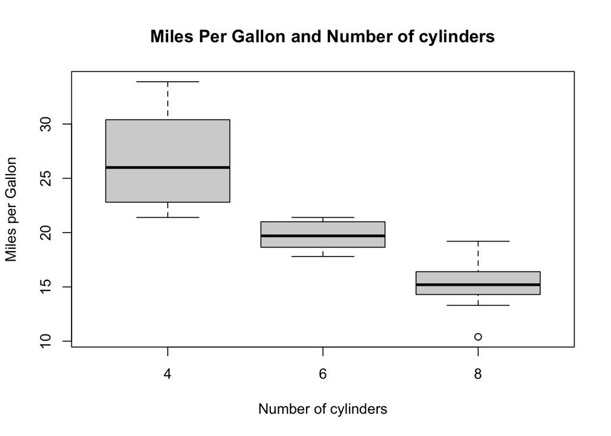

```r
boxplot(mpg~cyl,data=mtcars, main="Miles Per Gallon and Number of cylinders",
        xlab="Number of cylinders", ylab="Miles per Gallon")
```

**ZADANIE 5**

Instaluję pakiet, który jest przydatnym narzędziem statystycznym dla psychologów

```r
library(psych)
```

Korzystam z funkcji describe()

```r
describe(mtcars)
```

```
##      vars  n   mean     sd median trimmed    mad   min    max  range  skew
## mpg     1 32  20.09   6.03  19.20   19.70   5.41 10.40  33.90  23.50  0.61
## cyl     2 32   6.19   1.79   6.00    6.23   2.97  4.00   8.00   4.00 -0.17
## disp    3 32 230.72 123.94 196.30  222.52 140.48 71.10 472.00 400.90  0.38
## hp      4 32 146.69  68.56 123.00  141.19  77.10 52.00 335.00 283.00  0.73
## drat    5 32   3.60   0.53   3.70    3.58   0.70  2.76   4.93   2.17  0.27
## wt      6 32   3.22   0.98   3.33    3.15   0.77  1.51   5.42   3.91  0.42
## qsec    7 32  17.85   1.79  17.71   17.83   1.42 14.50  22.90   8.40  0.37
## vs      8 32   0.44   0.50   0.00    0.42   0.00  0.00   1.00   1.00  0.24
## am      9 32   0.41   0.50   0.00    0.38   0.00  0.00   1.00   1.00  0.36
## gear   10 32   3.69   0.74   4.00    3.62   1.48  3.00   5.00   2.00  0.53
## carb   11 32   2.81   1.62   2.00    2.65   1.48  1.00   8.00   7.00  1.05
##      kurtosis    se
## mpg     -0.37  1.07
## cyl     -1.76  0.32
## disp    -1.21 21.91
## hp      -0.14 12.12
## drat    -0.71  0.09
## wt      -0.02  0.17
## qsec     0.34  0.32
## vs      -2.00  0.09
## am      -1.92  0.09
## gear    -1.07  0.13
## carb     1.26  0.29
```

Czym różni się funkcja describe() od funkcji summary()?

Summary() to funkcja, która służy do uzyskiwania podstawowych statystyk opisowych. Funkcja describe() ma na celu ukazania statystyk potrzebnych w badaniach dotyczących psychologii, przedstawia je w ramce danych.

Wykorzystuję funkcję describeBy() grupując auta np. według liczby cylindrów

```r
describeBy(mtcars ~ cyl)
```

```
##
##  Descriptive statistics by group
## cyl: 4
##      vars  n   mean    sd median trimmed   mad   min    max range  skew
## mpg     1 11  26.66  4.51  26.00   26.44  6.52 21.40  33.90 12.50  0.26
## cyl     2 11   4.00  0.00   4.00    4.00  0.00  4.00   4.00  0.00   NaN
## disp    3 11 105.14 26.87 108.00  104.30 43.00 71.10 146.70 75.60  0.12
## hp      4 11  82.64 20.93  91.00   82.67 32.62 52.00 113.00 61.00  0.01
## drat    5 11   4.07  0.37   4.08    4.02  0.34  3.69   4.93  1.24  1.00
## wt      6 11   2.29  0.57   2.20    2.27  0.54  1.51   3.19  1.68  0.30
## qsec    7 11  19.14  1.68  18.90   18.99  1.48 16.70  22.90  6.20  0.55
## vs      8 11   0.91  0.30   1.00    1.00  0.00  0.00   1.00  1.00 -2.47
## am      9 11   0.73  0.47   1.00    0.78  0.00  0.00   1.00  1.00 -0.88
## gear   10 11   4.09  0.54   4.00    4.11  0.00  3.00   5.00  2.00  0.11
## carb   11 11   1.55  0.52   2.00    1.56  0.00  1.00   2.00  1.00 -0.16
##      kurtosis   se
## mpg     -1.65 1.36
## cyl       NaN 0.00
## disp    -1.64 8.10
## hp      -1.71 6.31
## drat     0.12 0.11
## wt      -1.36 0.17
## qsec    -0.02 0.51
## vs       4.52 0.09
## am      -1.31 0.14
## gear    -0.01 0.16
## carb    -2.15 0.16
## ------------------------------------------------------------
## cyl: 6
##      vars n   mean    sd median trimmed   mad    min    max  range  skew
## mpg     1 7  19.74  1.45  19.70   19.74  1.93  17.80  21.40   3.60 -0.16
## cyl     2 7   6.00  0.00   6.00    6.00  0.00   6.00   6.00   0.00   NaN
## disp    3 7 183.31 41.56 167.60  183.31 11.27 145.00 258.00 113.00  0.80
## hp      4 7 122.29 24.26 110.00  122.29  7.41 105.00 175.00  70.00  1.36
## drat    5 7   3.59  0.48   3.90    3.59  0.03   2.76   3.92   1.16 -0.74
## wt      6 7   3.12  0.36   3.21    3.12  0.36   2.62   3.46   0.84 -0.22
## qsec    7 7  17.98  1.71  18.30   17.98  1.90  15.50  20.22   4.72 -0.12
## vs      8 7   0.57  0.53   1.00    0.57  0.00   0.00   1.00   1.00 -0.23
## am      9 7   0.43  0.53   0.00    0.43  0.00   0.00   1.00   1.00  0.23
## gear   10 7   3.86  0.69   4.00    3.86  0.00   3.00   5.00   2.00  0.11
```

[output cut: 24 more lines]

```
## am      9 14   0.14  0.36   0.00    0.08  0.00   0.00   1.00   1.00  1.83
## gear   10 14   3.29  0.73   3.00    3.17  0.00   3.00   5.00   2.00  1.83
## carb   11 14   3.50  1.56   3.50    3.25  0.74   2.00   8.00   6.00  1.48
##      kurtosis    se
## mpg     -0.57  0.68
## cyl       NaN  0.00
## disp    -1.26 18.11
## hp       0.09 13.62
## drat     1.08  0.10
## wt      -0.71  0.20
## qsec    -0.92  0.32
## vs        NaN  0.00
## am       1.45  0.10
## gear     1.45  0.19
## carb     2.24  0.42
```

**ZADANIE 6**

Generuję 20 wyników rzutu kostką do gry

```r
proba <- sample(1:6, 20, replace = TRUE)
```

```r
proba
```

```
##  [1] 1 4 3 2 3 6 6 4 1 4 3 2 2 2 2 2 2 1 1 6
```

Nasza próba wynosi: 1, 4, 3, 2, 3, 6, 6, 4, 1, 4, 3, 2, 2, 2, 2, 2, 2, 1, 1, 6.

Średnia próby wynosi 2.85. Odchylenie standardowe wynosi 1.6630663.

Generuje 100 rzutów monetą

```r
rzut <- sample(0:1, 100, replace = TRUE)
```

```r
rzut # 1 to orzeł, 0 to reszka
```

```
##   [1] 1 0 1 1 1 1 1 1 0 1 1 1 0 0 1 0 1 1 1 1 1 0 0 0 0 0 0 1 1 0 1 0 1 0 0 0 0
##  [38] 1 1 1 1 1 0 0 0 1 1 0 0 0 0 0 1 0 1 0 0 1 0 1 0 1 0 1 1 0 0 0 1 0 1 1 1 1
##  [75] 1 1 0 1 0 0 1 1 0 1 0 0 1 0 0 1 0 0 0 0 0 1 1 0 1 1
```

Ile wypadło orłów?

```r
sum(rzut[rzut == 1])
```

```
## [1] 51
```

Wypadło 51 orłów.

Losujemy bez zwracania 10 liczb ze zbioru 0-100

```r
los <- sample(0:100, 10, replace = FALSE)
```

Nasze losowe liczby prezentują się tak: 25, 97, 86, 49, 87, 21, 17, 100, 3, 61.

Wykorzystuję funkcję rt()

```r
rt(5, 2, 1:10)
```

```
## [1]  2.915132 35.674460  4.432348 18.130775  7.082842
```

**ZADANIE 7**

Tworzę listę

```r
lista <- list(palenie <- c(F,T,T,F,F,T,F),
              cyfry <- 0:9,
              macierz <- matrix(sample(1:5,16,replace = T),4,4),
              tekst <- c("Litwo", "ojczyzno", "moja", "ty",
                         "jestes", "jak", "zdrowie"))
```

Odwołuję się do obiektu tekst

```r
lista[[4]]
```

```
## [1] "Litwo"    "ojczyzno" "moja"     "ty"       "jestes"   "jak"      "zdrowie"
```

Odwołuję się do trzeciego elementu wektora cyfry

```r
lista[[2]][[3]]
```

```
## [1] 2
```

Odwołuję się do trzeciej kolumny obiektu macierz

```r
macierz[,3]
```

```
## [1] 1 5 5 2
```

**ZADANIE 8**

Sprawdzanie czy liczba jest podzielna przez 4 (zakładam, że znam tą liczbę, przypisuję wartość)

```r
x <- 9
```

```r
if(x%%4 == 0){
  print("Liczba podzielna przez 4")
} else if (x%%4 != 0 ){
  print("Liczba niepodzielna przez 4")

}
```

```
## [1] "Liczba niepodzielna przez 4"
```

**ZADANIE 9** Tworzymy zmienną ksiązki

```r
ksiazki <- sample(0:4, size = 25, replace = TRUE)
```

```r
ksiazki
```

```
##  [1] 2 0 3 4 0 4 0 3 2 0 0 3 1 4 0 4 1 0 1 1 2 4 1 0 2
```

Średnia liczba przeczytanych książek wynosi 1.68.

Przynajmniej 3 książki przeczytało 8 czytelników.

Żadnej książki nie przeczytało 8 czytelników.

**ZADANIE 10**  
Funkcja, która zamienia temperaturę w Celsjuszach na temperaturę w Kelwinach i Fahrenheita

Funkcja C na K

```r
celsius_to_kelvin <- function(temp_C) {
  temp_K <- temp_C + 273.15
  return(temp_K)
}
```

0 stopni C to 273.15 stopni Kelwina.

Funkcja C na F

```r
celcius_to_fahrenheit <- function(tempC) {
  temp_F <- (9/5)* tempC + 32
  return(temp_F)
}
```

20 stopni C to 68 stopni Fahrenheita.

**ZADANIE 11**  
Funkcja, która na podstawie długości boków trójkąta, wyznacza jego pole

Wpisujemy trzy boki trójkąta

```r
a = as.integer(readline(prompt = "Wpisz długość pierwszego boku:"))
```

```
## Wpisz długość pierwszego boku:
```

```r
b = as.integer(readline(prompt = "Wpisz długość drugiego boku:"))
```

```
## Wpisz długość drugiego boku:
```

```r
c = as.integer(readline(prompt = "Wpisz długość trzeciego boku:"))
```

```
## Wpisz długość trzeciego boku:
```

Zmienna p we wzorze na pole

```r
p <- (a+b+c)/2
```

Tworzę funkcję

```r
poletrojkata <- function(p){
  pole <- sqrt(p*(p-a)*(p-b)*(p-b))
  return(pole)
}
```

**ZADANIE 12**

Tworzę funkcję, która pozwoli na sprawdzenie, czy dany trójkąt jest rozwartokątny, ostrokątny lub prostokątny (lub czy to w ogóle może być trójkąt)

```r
trojkat <- function(a,b,c){
  if(a+b >c && a+c >b && c+b >a){
  if(a<=b && b<=c){
    if(a^2+b^2<c^2){
      print("Trójkąt rozwartokątny")
    } else if(a^2+b^2>c^2){
      print("Trójkąt ostrokątny")
    } else{
      print("Trójkąt prostokątny")
    }
  } else {
    print("Wpisz boki trójkąta (od najkrótszego do najdłużeszgo)")
  }
  }else{
    print("To nie jest trójkąt")}
}
```

Sprawdzam trójkąt o bokach 2,3,4

```r
trojkat(2,3,4)
```

```
## [1] "Trójkąt rozwartokątny"
```